# Bioassay Analysis Report

# ELISA Analysis Report

AuthorsKristof Moeller (IAEA, Monaco) · Arnold Molina Porras (Universidad de Costa Rica)

Generated2026-05-15 · root

AssayELISA — cortisol

SoftwareBioassay Analysis App v2.0 · R version 4.3.3 (2024-02-29) · drc v3.2.0

This report analyzes ELISA data using a four-parameter logistic dose–response curve to estimate concentrations of cortisol in unknown samples.

**Method: Competitive enzyme-linked immunosorbent assay with %B/B0 normalization**

## Analysis Notes

*No additional notes provided.*

## Standard Curve Configuration

**Standard Concentrations**

Standard Concentrations

| Standards | Concentration (pg/mL) |
| --- | --- |
| 1 | 4,000.0 |
| 2 | 1,600.0 |
| 3 | 640.0 |
| 4 | 256.0 |
| 5 | 102.4 |
| 6 | 41.0 |
| 7 | 16.4 |
| 8 | 6.6 |

## Methods

**Curve model:** Four-parameter log-logistic (LL.4) as implemented in the drc package (v3.2.0; Ritz et al. 2015). If LL.4 fails to converge a three-parameter model (LL.3, fixed lower asymptote = 0) is attempted; if neither converges, linear interpolation is used as a fallback.

**Weighting:** Unweighted (ordinary least squares).

**Outlier detection:** Not applied; all replicates included in group statistics.

**Software:** Bioassay Analysis App v2.0 R version 4.3.3 (2024-02-29) drc v3.2.0

## Dose–Response Curve Analysis

Analyst:**root**

Analysis Date:**2026-05-15**

Wells**72 samples / 16 standards**

ELISA Control Wells**Valid**

R curve fit

0.9976

RMSE

1.827

Cal. low

41

pg/mL

Cal. high

1,600

pg/mL

Overall

All standards show acceptable variability (<30% CV).

**Quality Control Summary**

#### Quality Control Summary

*Regression: Unweighted (LL.4)*

### Weighting Suitability Assessment

**Test:** Brown-Forsythe (Levene, median)

**Statistic:** 1.000e+06   **p-value:** 2.2362e-122

**Variance ratio** (max/min across concentration levels): 729316.0

**Recommendation:** Weighted regression (1/Y or 1/Y) is recommended to account for unequal variance.

*Note: This diagnostic is advisory only and does not change the selected model.*

**Limits of Quantification**

#### Limits of Quantification

**LLOQ (Lower Limit of Quantification):** 41 pg/mL

**ULOQ (Upper Limit of Quantification):** 1,600 pg/mL

**Dose–Response Curve Analysis**

[interactive chart not shown]

## Model Parameters

**Four-Parameter Logistic Model Coefficients**

Four-Parameter Logistic Model Coefficients

| Parameter | Estimate | Std. Error | p-value |
| --- | --- | --- | --- |
| Hill Slope | 1.25 | 0.08 | NA |
| Bottom | 1.87 | 1.72 | NA |
| Top | 100.00 | 1.40 | NA |
| IC50 | 205.23 | 10.93 | NA |

**Model Fit Statistics:**

### Standard Back-Calculation and Recovery

**Click to expand standard back-calculation and recovery**

Standard Back-Calculation and Recovery

| Nominal (pg/mL) | n | Back-Calc. (pg/mL) | SD (pg/mL) | Recovery (%) |
| --- | --- | --- | --- | --- |
| 4,000.0 | 2 | 5,145.13 | 954.93 | 128.63 |
| 1,600.0 | 2 | 1,547.32 | 131.00 | 96.71 |
| 640.0 | 2 | 618.10 | 0.18 | 96.58 |
| 256.0 | 2 | 259.38 | 19.31 | 101.32 |
| 102.4 | 2 | 105.21 | 11.38 | 102.75 |
| 41.0 | 2 | 38.52 | 3.83 | 93.94 |
| 16.4 | 2 | 25.21 | — | 153.70 |
| 6.6 | 2 | 15.27 | — | 231.36 |

**Overall Mean Recovery: 125.6%** Overall recovery is outside the typical acceptable range (80–120%). Review curve fit.

## Sample Concentration Results

**Data Quality Overview**  
Total wells: 96 | Standards: 16 | Samples: 72 | Controls: 7

### Detailed Sample Results Summary

† Lower bound truncated to 0 (original value was negative) for: AA, AC, AD, AE, AF, AG, BB, BC, BE, BF, BG, CA, CB, CC, CE, CF, CG, CH, DA, DB, DC, DD, DE, DF, DG, EA, EB, EC

**Output Files Created:** - `unknown_results.csv` - Individual well results - `unknown_results_summary.csv` - Replicate group statistics with confidence intervals

**⚠️ Quality Alert:** - Replicate groups with high variability (CV > 30%): AA, AC, AG, BB, CB, CC, CF, CH, DA, DB, DC, DD, DE, DF, DG, EA, EB, EC - Consider checking sample preparation or dilution consistency

*95% confidence intervals calculated using t-distribution.*

*Replicate-level CIs reflect measurement variability using Student’s t-distribution (df = n-1).*

*Individual sample concentrations include CIs from inverse prediction (delta method), accounting for curve-fitting uncertainty.*

*Lower confidence bounds are constrained to zero, as negative concentrations have no biological meaning. This may result in asymmetric confidence intervals.*

## Detailed Sample Results Summary

**Detailed Sample Results Summary**

##### How to read this table

The **Range** column flags whether a sample’s mean concentration falls within the calibration curve:

Row colouring is independent of the Range flag and indicates measurement quality:

A row can carry both treatments if it is both out-of-range and imprecise.

Detailed Sample Results with Model-Based Confidence Intervals

[output not shown]

## Sample Variability Visualization

**Sample variability visualization**

*Box-and-jitter plot showing estimated concentrations per replicate group. Points are colored by whether they fall within the validated linear range. Use this to assess replicate consistency and identify outliers.*

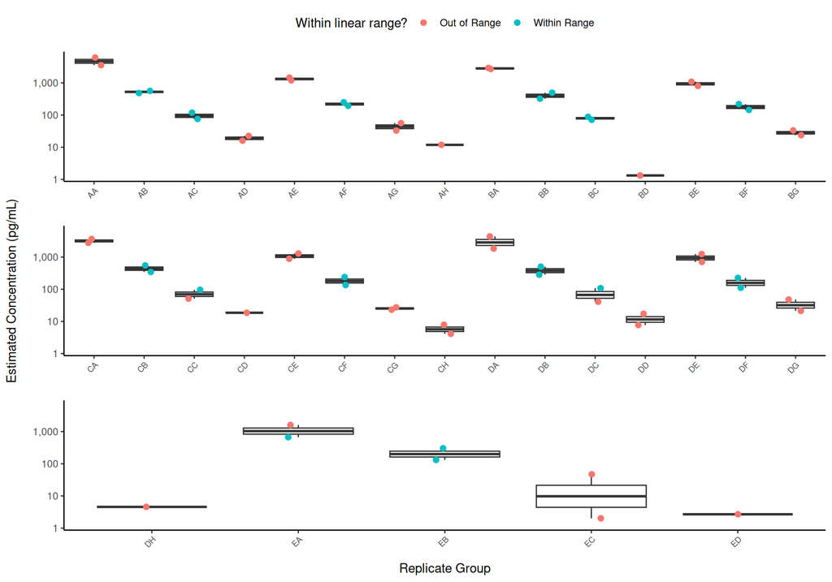

## Plate Heatmap

**Plate Heatmap**

Visual representation of raw measurement values across the plate.

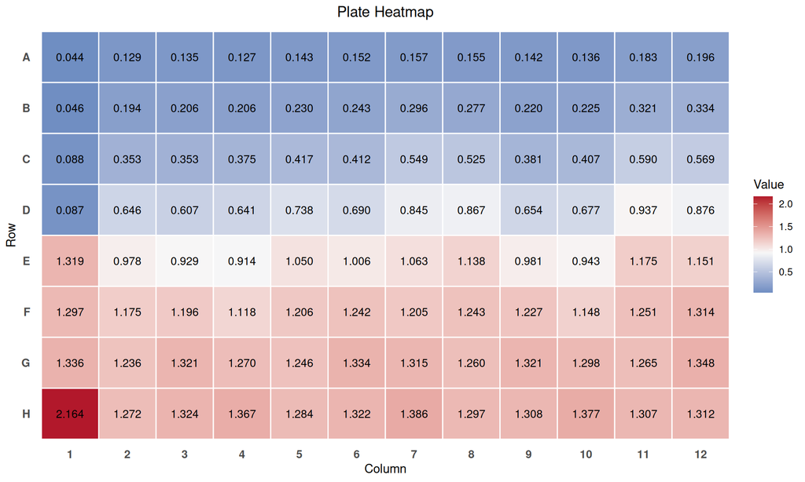

**Click to expand plate positional quality**

#### Plate Positional Quality

No significant row or column bias detected (all within 2 SD of plate mean).

Response by Row

| Row | Mean Response | SD | Flag |
| --- | --- | --- | --- |
| A | 0.14 | 0.04 | OK |
| B | 0.23 | 0.07 | OK |
| C | 0.42 | 0.14 | OK |
| D | 0.69 | 0.22 | OK |
| E | 1.05 | 0.12 | OK |
| F | 1.22 | 0.06 | OK |
| G | 1.30 | 0.04 | OK |
| H | 1.39 | 0.24 | OK |

## Dose-Response Curve with Unknown Samples

**Dose-Response Curve with Unknown Samples**

[interactive chart not shown]

## Parallelism and Relative Potency

*Not applicable: Fewer than 2 independent standard curves available for parallelism testing.*

## Interpretation & Recommendations

**Quality warnings detected:** High sample CV (max 129.9% > 15% limit). Review flagged items before use.

> **Two independent range indicators appear in this report:**
> - **Interpolated / Extrapolated** refers to whether the estimated concentration falls within the range of fitted standard concentrations on this plate. This is a statement about curve coverage.
> - **Within range / ULOQ** refers to whether the estimate falls within the validated linear (quantifiable) range of the dose-response curve, defined by EC20/EC80 for RBA or %B/B0 bounds (default 20–80%) for ELISA. This is a statement about reporting quality.

> A sample can be interpolated but outside the quantifiable range (e.g., the response falls on the flat portion of the curve near the top or bottom asymptote), or within the quantifiable range but technically extrapolated (if the user provided few standards). Both flags should be considered when interpreting results.

**Quantification status breakdown (per well):**

- Extrapolated (above): 2
- Extrapolated (below): 5
- Interpolated: 58
- Not estimable: 7

*Note: Extrapolated values are outside the standard curve range and should be interpreted with caution.*

*QC profile: ELISA (R² >= 0.98, CV <= 15%, Hill slope [-3.0, -0.2], Recovery [80%, 120%])*

### Exclusion Audit

**Exclusion Audit Trail**

*No exclusions were applied during this analysis.*

**Abbreviations**

**RBA**

Radioligand Binding Assay

**ELISA**

Enzyme-Linked Immunosorbent Assay

**LL.4**

Four-parameter log-logistic dose-response function

**IC50**

Half-maximal inhibitory concentration

**EC20**

Concentration producing 20% of maximal response

**EC80**

Concentration producing 80% of maximal response

**%B/B0**

Percent bound relative to maximum specific binding (B0)

**B0**

Maximum specific binding (zero-standard well)

**NSB**

Non-specific binding

**LLOQ**

Lower Limit of Quantification

**ULOQ**

Upper Limit of Quantification

**Cal. high**

**Cal. low**

**CV**

Coefficient of variation between replicate wells, %. Replicates with CV > 30% are flagged with a red left-border on the row.

**SD**

Standard Deviation

**SE**

Standard Error of the Mean

**CI**

Confidence Interval

**Report Generated:** 2026-05-15 **Contact:** kr.moeller@iaea.org **Feedback:** [Online Form](https://forms.office.com/e/q8eqJfp4QM)

*Automated bioassay analysis using modular system v2.0*